# Case Study 2: University tuition

Kelly Bodwin

## Get the data

We will be attempting to find a linear regression that models college tuition rates, based on a dataset from US News and World Report. Alas, this data is from 1995, so it is very outdated; still, we will see what we can learn from it.

### Question 1:

1. The dataset is located at `http://kbodwin.web.unc.edu/files/2016/09/tuition_final.csv`; figure out how to use the code you were given last time for `read.csv( )` and `read.table( )` to read the data into **R** and call it `tuition`. Use the functions we learned last time to familiarize yourself with the data in `tuition`.

```r
  # YOUR CODE HERE
tuition = read.csv("http://kbodwin.web.unc.edu/files/2016/09/tuition_final.csv")
```

2. Make a new variable in `tuition` called `Acc.Rate` that contains the acceptance rate for each university.

```r
  # YOUR CODE HERE
tuition$Acc.Rate<- tuition$Accepted/tuition$Applied
```

3. Find and print the row of the data that corresponds to UNC (“University of North Carolina at Chapel Hill”).

```r
  # YOUR CODE HERE
tuition[tuition$Name == "University of North Carolina at Chapel Hill",]
```

```
##       ID                                        Name State Public Avg.SAT
## 682 2974 University of North Carolina at Chapel Hill    NC      1    1121
##     Avg.ACT Applied Accepted  Size Out.Tuition Spending  Acc.Rate
## 682      NA   14596     5985 14609        8400    15893 0.4100438
```

## Writing functions

We have seen many examples of using functions in **R**, like `summary( )` or `t.test( )`. Now you will learn how to write your *own* functions. Defining a function means writing code that looks something like this:

```r
my_function <- function(VAR_1, VAR_2){

  # do some stuff with VAR_1 and VAR_2
  return(result)

}
```

Then you run the code in **R** to “teach” it how your function works, and after that, you can use it like you would any other pre-existing function. For example, try out the following:

```r
add1 <- function(a, b){

  # add the variables
  c = a + b
  return(c)

}

add2 <- function(a, b = 3){

  # add the variables
  c = a + b
  return(c)

}

# Try adding 5 and 7
add1(5, 7)
add2(5, 7)

# Try adding one variable
add1(5)
add2(5)
```

### Question 2:

What was the effect of `b = 3` in the definition of `add2( )`?

```
instantiates variable b with number 3. The value 3 is stored in b so if no input is provided b defaults to 3.
```

### Question 3:

1. Recall that the equations for simple linear regression are:
   $$\beta_1 = r \frac{S_Y}{S_X} \hspace{0.5cm} \beta_0 = \bar{Y} - \beta_1 \bar{X}$$

Write your own functions, called `beta1( )` and `beta0( )` that take as input some combination of `Sx`, `Sy`, `r`, `y_bar`, and `x_bar`, and use that to calculate $\beta_1$ and $\beta_0$.

```r
  # YOUR CODE HERE
beta1 <- function(Sx, Sy, r) {

  return (r*(Sy/Sx))
}

beta0 <- function(Sx, Sy, r ,y_bar,x_bar) {
  if (Sx == 0) {
    return (NaN)
  } else{
    b1 = beta1(Sx,Sy,r)
    return (y_bar - b1*x_bar)
  }

}
```

2. Try your function with `Sx = 0`. Did it work? If not, fix your function code. Explain why it would be a problem to do linear regression with $S_X = 0$.

```
Dividing by 0 creates infinite. When calculating Beta 1 , dividing the std dev of y by a zero will not create a linear model;
```

## Linear Regression by hand

Use the code below to make a scatterplot of college tuition versus average SAT score.

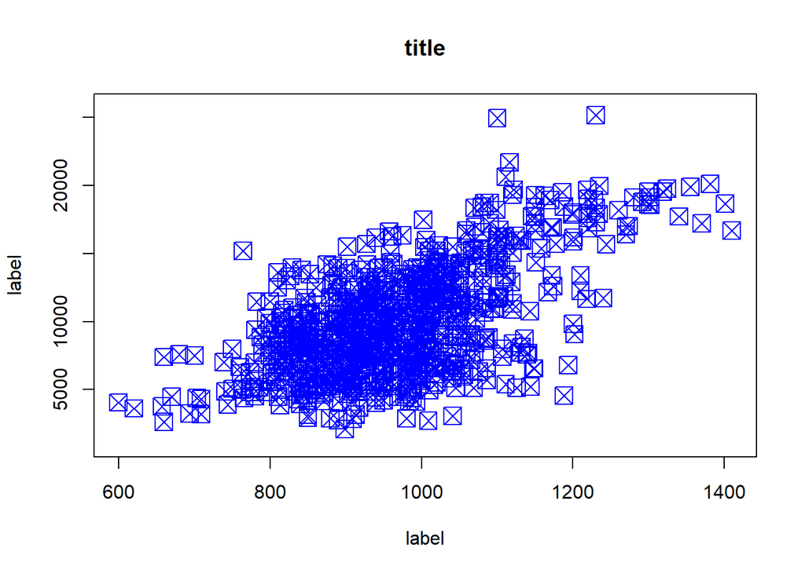

```r
plot(tuition$Avg.SAT, tuition$Out.Tuition, main = "title", xlab = "label", ylab = "label", pch = 7, cex = 2, col = "blue")
```

### Question 4:

1. Make your own scatterplot, but change the input of `plot( )` so that it looks nice.

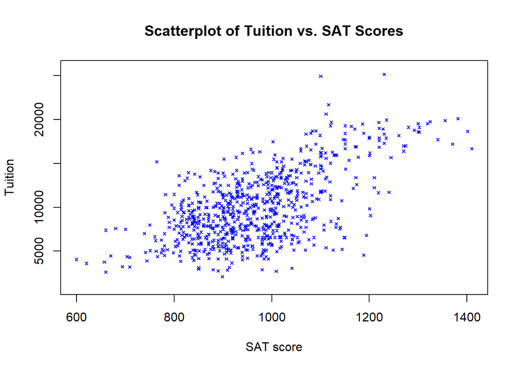

```r
  # YOUR CODE HERE
plot(tuition$Avg.SAT, tuition$Out.Tuition, main = "Scatterplot of Tuition vs. SAT Scores", xlab = "SAT score", ylab = "Tuition", pch = 4, cex = .5, col = "blue")
```

2. What do `pch` and `cex` do?

```
"cex changes the size of each point in the scatter plot and scales it based on the value. pch changes the symbol for each point"
```

3. We have used the function `abline( )` to add a vertical line or a horizontal line to a graph. However, it can also add lines by slope and intercept. Read the documentation of `abline( )` until you understand how to do this. Then add a line with slope 10 and intercept 0 to your plot.

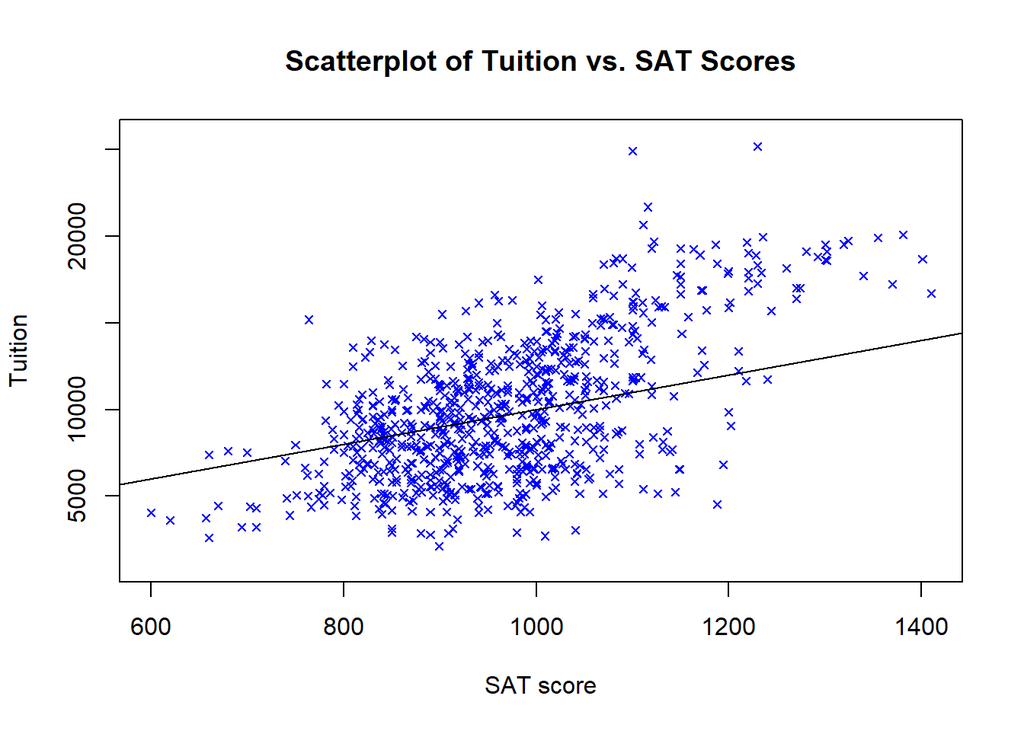

```r
  # YOUR CODE HERE
plot(tuition$Avg.SAT, tuition$Out.Tuition, main = "Scatterplot of Tuition vs. SAT Scores", xlab = "SAT score", ylab = "Tuition", pch = 4, cex = .7, col = "blue")

abline(a = 0, b = 10)
```

4. Does this line seem to fit the data well?

```
"The line does fit the data partially but needs adjustment to reflect a more accurate linear regression. "
```